# Лабораторная работа № 7

Анализ файловой системы Linux. Команды для работы с файлами и каталогами

Чжан Вэньцзюнь

Российский университет дружбы народов

2026-10-20

# Информация

## Докладчик

- Чжан Вэньцзюнь
- зачётная книжка № 1132259051
- Российский университет дружбы народов им. П. Лумумбы

## Цель работы

- Ознакомление с файловой системой Linux, её структурой, именами и содержимым каталогов
- Приобретение навыков применения команд для работы с файлами и каталогами
- Изучение прав доступа и команды `chmod`
- Анализ файловой системы: `mount`, `df`, `/etc/fstab`, `fsck`

## Задание

1. Выполнить примеры первой части методических указаний
2. Выполнить пп. 2.1–2.8 (копирование, перемещение, переименование)
3. Задать права доступа файлам и каталогам (пп. 3.1–3.4)
4. Выполнить упражнения пп. 4.1–4.12
5. Изучить `man` по командам `mount`, `fsck`, `mkfs`, `kill`

# Выполнение работы

## Среда выполнения

- Fedora Linux 44 (Sway), ядро `6.19.10-300.fc44.x86_64`
- Пользователь `vzhang`, домашний каталог `/home/vzhang`
- Виртуальная машина VirtualBox

| Устройство | ФС | Точка монтирования |
| --- | --- | --- |
| `/dev/sda2` | `ext4` | `/boot` |
| `/dev/sda3` | `crypto_LUKS` → `btrfs` | `/`, `/home` |
| `/dev/zram0` | `swap` | — |
| `vmshare` | `vboxsf` | `/mnt/vmshare` |

## Работа с файлами и каталогами

```bash
cp /usr/include/sys/io.h ~/equipment
mkdir ~/ski.plases
mv ~/equipment ~/ski.plases/
mv ~/ski.plases/equipment ~/ski.plases/equiplist
cp ~/abc1 ~/ski.plases/equiplist2
mv ~/ski.plases/equiplist ~/ski.plases/equiplist2 \
   ~/ski.plases/equipment/
mkdir ~/newdir
mv ~/newdir ~/ski.plases/plans
```

## Результат работы с файлами

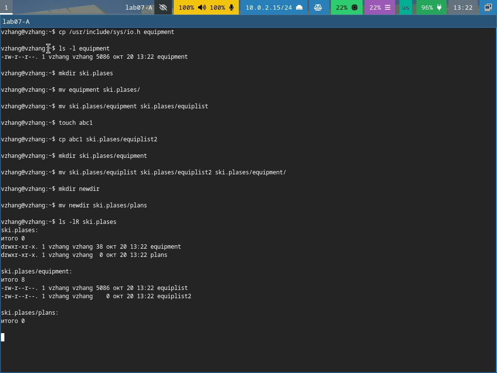

Работа с файлами и каталогами (пп. 2.1–2.8)

## Переименование и перемещение

- `mv old new` в пределах каталога — **переименование** записи каталога, данные не копируются
- `mv` между разными ФС — копирование с последующим удалением источника
- `cp` без опции `-r` не копирует каталог

```bash
mv ~/ski.plases/equipment ~/ski.plases/equiplist   # переименование
mv ~/newdir ~/ski.plases/plans                     # перемещение + переименование
```

## Права доступа: восьмеричная запись

| Задание | Восьм. | Символьная |
| --- | --- | --- |
| `drwxr--r--` … `australia` | `744` | `rwx r-- r--` |
| `drwx--x--x` … `play` | `711` | `rwx --x --x` |
| `-r-xr--r--` … `my_os` | `544` | `r-x r-- r--` |
| `-rw-rw-r--` … `feathers` | `664` | `rw- rw- r--` |

## Эксперименты с правами доступа

```bash
chmod u-r ~/feathers
cat ~/feathers        # Отказано в доступе
cp ~/feathers ~/f2    # Отказано в доступе
chmod u+r ~/feathers  # -rw-rw-r--

chmod u-x ~/play
cd ~/play             # Отказано в доступе
chmod u+x ~/play      # drwx--x--x
```

## Результат экспериментов с правами

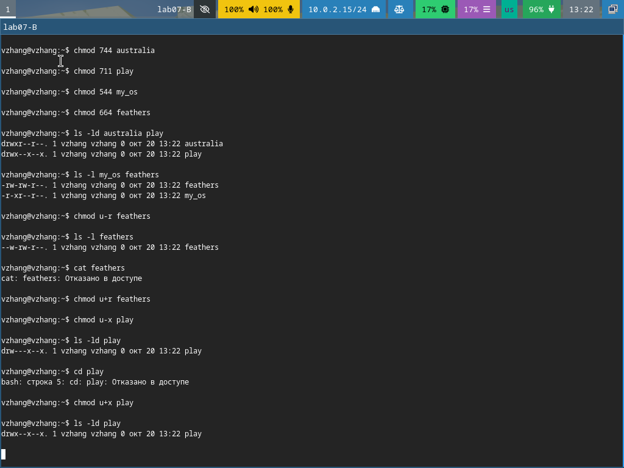

Эксперименты с правами доступа

## Смысл битов для каталога

- `r` — просмотр списка имён в каталоге
- `w` — создание и удаление файлов в каталоге
- `x` — **доступ к записям** каталога, возможность сделать его текущим
- Без `x` каталог нельзя открыть и обойти, даже если список имён читается
- Владелец файла не может обойти установленные права (в отличие от `root`)

## Команды обслуживания файловой системы

| Команда | Назначение | Пример |
| --- | --- | --- |
| `mount` | монтирование и просмотр ФС | `mount /dev/sdb1 /mnt/data` |
| `fsck` | проверка и восстановление ФС | `fsck /dev/sda2` |
| `mkfs` | создание файловой системы | `mkfs -t ext4 /dev/sdb1` |
| `kill` | сигнал процессу | `kill -9 1234` |

- `fsck` применяют к **размонтированной** ФС
- `mount -a` монтирует всё из `/etc/fstab`

## Анализ файловой системы

```bash
mount | head -8
df -h
cat /etc/fstab
```

- `/dev/dm-0` (`btrfs`, 38 ГБ) — `/` и `/home`, занято 12%
- `/dev/sda2` (`ext4`, 2,0 ГБ) — `/boot`, занято 22%
- `vmshare` (`vboxsf`, 200 ГБ) — `/mnt/vmshare`
- `/etc/fstab`: записи по UUID, опции `subvol=`, `compress=zstd:1`

# Заключение

## Выводы

- Изучена структура файловой системы Linux и назначение каталогов первого уровня
- Определены типы ФС на дисках: `btrfs` в LUKS, `ext4` для `/boot`, `vboxsf` для `/mnt/vmshare`
- Освоены команды `cp`, `mv`, `mkdir`, `touch`, `ls`, `cat`
- Изучено управление правами доступа `chmod` (символьная и восьмеричная формы)
- Подтверждён смысл битов `r`, `w`, `x` для файлов и каталогов
- Рассмотрены `mount`, `fsck`, `mkfs`, `kill`, `df`, `/etc/fstab`

## Спасибо за внимание!

Вопросы?